# Tenth Week: Principal Component Analysis and Factor Analysis

PCA Stock, image, …

Mohammadmahdi Faryabi - STD-ID: 93101951

2018-05-20 01:37:18

> با استفاده از داده های OHLCV شرکت های تشکیل دهنده شاخص s&p500 و همچنین داده مربوط به شاخص های اقتصادی به سوالات زیر پاسخ دهید.

> Loading required packages and data.

```r
library(readr)
library(ggbiplot)
library(dplyr)
library(highcharter)
library(stringr)
library(tidyr)


constituents <- read_csv('../class_data/constituents.csv')
file_names <- list.files('../class_data/stock_dfs/') %>% str_replace('.csv', '')
file_paths <- list.files('../class_data/stock_dfs/', full.names = TRUE)

# stocks_data <- data.frame()
# for (i in 1:length(file_names)) {
#   company_data <- read_csv(file_paths[i]) %>%
#     select(Date, Open, Close, Volume) %>% mutate(Symbol = file_names[i])
#   rbind(stocks_data, company_data) -> stocks_data
#   print(i)
# }

# save(stocks_data, file = 'saved_data/stocks_data.RData')
load('../saved_data/stocks_data.RData')


# stocks_data_full <- data.frame()
# for (i in 1:length(file_names)) {
#   company_data <- read_csv(file_paths[i]) %>% mutate(Symbol = file_names[i])
#   rbind(stocks_data_full, company_data) -> stocks_data_full
#   print(i)
# }

# save(stocks_data_full, file = 'saved_data/stocks_data_full.RData')
load('../saved_data/stocks_data_full.RData')
```

۱. چه شرکتی رکورددار کسب بیشترین سود در بازه یکساله، دو ساله و پنج ساله می باشد؟ این سوال را برای بخش های مختلف مورد مطالعه قرار دهید و رکورددار را معرفی کنید. (برای این کار به ستون sector داده constituents مراجعه کنید.) برای هر دو قسمت نمودار سود ده شرکت و یا بخش برتر را رسم نمایید.

```r
########################################################################################
#### Q1

get_company_revenues <- function(i) {
  company_data <- read_csv(file_paths[i])
  company_name <- file_names[i]

  first_date <- company_data %>% arrange(Date) %>% summarise(date = first(Date))
  first_date <- first_date$date[[1]]

  last_date <- company_data %>% arrange(Date) %>% .[complete.cases(.),] %>% summarise(date = last(Date))
  last_date <- last_date$date[[1]]

  all_dates <- seq(from=first_date, to=last_date, by = 'days') %>% as.data.frame() %>% rename(Date = '.')


  all_dates %>% full_join(company_data, by = 'Date') %>%
    mutate(OneYearRev = NA, TwoYearRev = NA, FiveYearRev = NA) -> company_data_all_dates

  for (i in 1:nrow(company_data_all_dates)) {
    if (company_data_all_dates[i,]$Open %>% is.na) {
      company_data_all_dates[i,2:7] <- company_data_all_dates[i-1,2:7]
    }
    if (i > 365) {
      company_data_all_dates$OneYearRev[i] <- company_data_all_dates$Volume[i] - company_data_all_dates$Volume[(i-365)]
    }
    if (i > (365*2)) {
      company_data_all_dates$TwoYearRev[i] <- company_data_all_dates$Volume[i] - company_data_all_dates$Volume[(i-(365*2))]
    }
    if (i > (365*5)) {
      company_data_all_dates$FiveYearRev[i] <- company_data_all_dates$Volume[i] - company_data_all_dates$Volume[(i-(365*5))]
    }
    # print(i)
  }

  rbind(
    company_data_all_dates %>% arrange(desc(OneYearRev)) %>% slice(1) %>% select(Date, Revenue = OneYearRev) %>% mutate(Duration = 1),
    company_data_all_dates %>% arrange(desc(TwoYearRev)) %>% slice(1) %>% select(Date, Revenue = TwoYearRev) %>% mutate(Duration = 2),
    company_data_all_dates %>% arrange(desc(FiveYearRev)) %>% slice(1) %>% select(Date, Revenue = FiveYearRev) %>% mutate(Duration = 5)
  ) %>% mutate(Symbol = company_name) -> result

  return(result)
}

# company_revenue_data <- data.frame()
# n <- length(file_names)
# for (i in 1:n) {
#   rbind(company_revenue_data, get_company_revenues(i)) -> company_revenue_data
#   print(paste(i, 'out of', n))
# }


# save(company_revenue_data, file = 'saved_data/company_revenue_data.RData')
load('../saved_data/company_revenue_data.RData')

company_revenue_data %>% full_join(constituents, by = 'Symbol') %>%
  filter(Duration == 1) %>% group_by(Sector) %>% top_n(1, Revenue) %>% arrange(desc(Revenue)) %>% .[complete.cases(.),] %>%
  hchart(type = 'column', hcaes(x =  paste(Name, ':' , Sector), y = Revenue)) %>% hc_title(text = 'Revenue over 1 year')
```

[interactive chart not shown]

```r
company_revenue_data %>% full_join(constituents, by = 'Symbol') %>%
  filter(Duration == 2) %>% group_by(Sector) %>% top_n(1, Revenue) %>% arrange(desc(Revenue)) %>% .[complete.cases(.),] %>%
  hchart(type = 'column', hcaes(x = paste(Name, ':' , Sector), y = Revenue)) %>% hc_title(text = 'Revenue over 2 years')
```

[interactive chart not shown]

```r
company_revenue_data %>% full_join(constituents, by = 'Symbol') %>%
  filter(Duration == 5) %>% group_by(Sector) %>% top_n(1, Revenue) %>% arrange(desc(Revenue)) %>% .[complete.cases(.),] %>%
  hchart(type = 'column', hcaes(x = paste(Name, ':' , Sector), y = Revenue)) %>% hc_title(text = 'Revenue over 5 years')
```

[interactive chart not shown]

```r
rbind(
  company_revenue_data %>% full_join(constituents, by = 'Symbol') %>%
    filter(Duration == 1) %>% group_by(Sector) %>% top_n(1, Revenue) %>% arrange(desc(Revenue)),
  company_revenue_data %>% full_join(constituents, by = 'Symbol') %>%
    filter(Duration == 2) %>% group_by(Sector) %>% top_n(1, Revenue) %>% arrange(desc(Revenue)),
  company_revenue_data %>% full_join(constituents, by = 'Symbol') %>%
    filter(Duration == 5) %>% group_by(Sector) %>% top_n(1, Revenue) %>% arrange(desc(Revenue))
) %>% .[complete.cases(.),] %>%
  hchart(type = 'column', hcaes(x = paste(Name, ':' , Sector), y = Revenue, group = Duration))
```

[interactive chart not shown]

۲. یک اعتقاد خرافی می گوید خرید سهام در روز سیزدهم ماه زیان آور است. این گزاره را مورد ارزیابی قرار دهید.

> In order to challenge this hypothesis we’ve devided our data of stocks into two groups.  
> First, changes of stock prices in the 13th days of months of years.  
> Second, changes of stock prices in the other days of months of years.  
> The null hypothesis is that these two come from a normal distribution with the same mean.  
> P-value of the hypothesis test is considerably high so we cannot reject this hypothesis.  
> According to the mean of each group. if we wanted to choose between 13th days of month and another day of it to spend our money on stocks, we would be better off doing it in the 13th day!

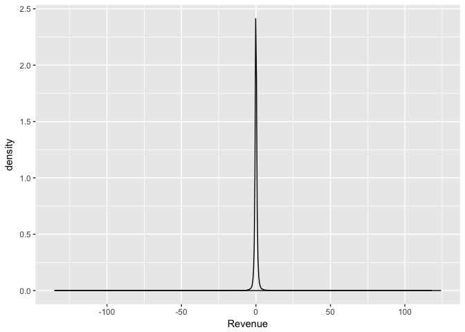

```r
########################################################################################
#### Q2

library(ggplot2)

stocks_data %>% filter((Date %>% gdata::getDay()) == 13) %>% mutate(Revenue = Close - Open) %>%
  ggplot(aes(x = Revenue)) + geom_density()
```

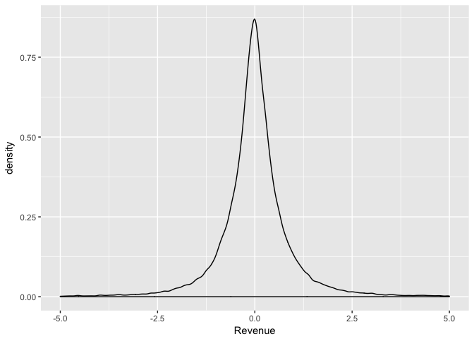

```r
stocks_data %>% filter((Date %>% gdata::getDay()) == 13) %>% mutate(Revenue = Close - Open) %>% filter(abs(Revenue) < 5) %>%
  ggplot(aes(x = Revenue)) + geom_density()
```

```r
stocks_data %>% mutate(is13th = (Date %>% gdata::getDay()) == 13) %>% mutate(Revenue = Close - Open) -> q2_revenue_data
t.test(Revenue~is13th, data = q2_revenue_data) %>% print
```

```
##
##  Welch Two Sample t-test
##
## data:  Revenue by is13th
## t = -1.1301, df = 70550, p-value = 0.2585
## alternative hypothesis: true difference in means is not equal to 0
## 95 percent confidence interval:
##  -0.024518595  0.006585324
## sample estimates:
## mean in group FALSE  mean in group TRUE
##          0.01206949          0.02103613
```

۳. رکورد بیشترین گردش مالی در تاریخ بورس برای چه روزی بوده است و چرا!!!

> The record for financial turnaround in the history of american stocks is set at the center of american financial crisis.  
> One possible cause would be people’s hurry to sell the stocks of companies that were on the verge of bankrupcy or to exchange their investments for gaining profit in the unstable markets of that days.

```r
########################################################################################
#### Q3

get_company_voldiffs <- function(i) {
  company_data <- read_csv(file_paths[i])
  company_name <- file_names[i]

  company_data %>% mutate(RevenueDiff = NA) -> company_data

  for (i in 2:nrow(company_data)) {
    company_data$RevenueDiff[i] <- company_data$Volume[i] - company_data$Volume[i-1]
  }

  company_data %>% mutate(Symbol = company_name) -> company_data

  return(company_data)
}

# company_data_voldiffs <- data.frame()
# n <- length(file_names)
# for (i in 1:n) {
#   rbind(company_data_voldiffs, get_company_voldiffs(i)) -> company_data_voldiffs
#   print(paste(i, 'out of', n))
# }
# save(company_data_voldiffs, file = 'saved_data/company_data_voldiffs.RData')
load('../saved_data/company_data_voldiffs.RData')

company_data_voldiffs %>% mutate(AbsRevenue = abs(RevenueDiff)) %>% group_by(Date) %>%
  summarise(Turnover = sum(as.numeric(AbsRevenue), na.rm = TRUE)) %>% arrange(desc(Turnover)) %>% ungroup %>% slice(1:10) -> q3_chart_data

q3_chart_data %>% hchart(type = 'column', hcaes(x = Date, y = Turnover))
```

[interactive chart not shown]

```r
q3_chart_data$Date <- q3_chart_data$Date %>% as.factor
q3_chart_data %>% hchart(type = 'column', hcaes(x = Date, y = Turnover))
```

[interactive chart not shown]

۴. شاخص AAPL که نماد شرکت اپل است را در نظر بگیرید. با استفاده از رگرسیون خطی یک پیش کننده قیمت شروع (open price) بر اساس k روز قبل بسازید. بهترین انتخاب برای k چه مقداری است؟ دقت پیش بینی شما چقدر است؟

> According to the graph of min squre error of our model versus the ‘k’ value, best value for ‘k’, yielding smallest error is with k = 119.

```r
########################################################################################
#### Q4

stocks_data %>% filter(Symbol == 'AAPL') %>% arrange(desc(Date)) %>% select(Open) %>% rename(Price = Open) -> apple_open_prices

mse <- function(model) {
  result = mean(model$residuals^2)
  return(result)
}

get_model_data <- function(k) {
  cbind(
    apple_open_prices,
    apple_open_prices %>% .$Price %>% lead %>% as.data.frame %>% dplyr::rename(Day1 = '.')
  ) -> model_data
  column_names <- c('Day1')
  if (k > 1) {
    for (i in 2:k) {
      cbind(
        model_data,
        model_data %>% .$Day1 %>% lead %>% as.data.frame
      ) -> model_data
      column_names <- c(paste('Day', i, sep = ''), column_names)
      colnames(model_data) <- c('Price', column_names)
    }
  }
  return(model_data)
}

find_mse_for_kday_model <- function(k) {
  model_data <- k %>% get_model_data
  model <- lm(Price~., data = model_data)
  result <- model %>% mse
  return(result)
}


x = 1:300
y = sapply(x, find_mse_for_kday_model)

data.frame(number_of_days = x, mean_square_error = y) %>%
  hchart(type = 'line', hcaes(x = number_of_days, y = mean_square_error))
```

[interactive chart not shown]

```r
# minimum error is for 119 days of lookback


library(h2o)
h2o.init()
```

```
##
## H2O is not running yet, starting it now...
##
## Note:  In case of errors look at the following log files:
##     /var/folders/98/w58pw87s2bv03csh9hsjytd00000gn/T//Rtmp3rg5VA/h2o_mohammadmahdi_started_from_r.out
##     /var/folders/98/w58pw87s2bv03csh9hsjytd00000gn/T//Rtmp3rg5VA/h2o_mohammadmahdi_started_from_r.err
##
##
## Starting H2O JVM and connecting: .............. Connection successful!
##
## R is connected to the H2O cluster:
##     H2O cluster uptime:         20 seconds 600 milliseconds
##     H2O cluster timezone:       Asia/Tehran
##     H2O data parsing timezone:  UTC
##     H2O cluster version:        3.19.0.4257
##     H2O cluster version age:    1 month and 11 days
##     H2O cluster name:           H2O_started_from_R_mohammadmahdi_zpj824
##     H2O cluster total nodes:    1
##     H2O cluster total memory:   1.78 GB
##     H2O cluster total cores:    0
##     H2O cluster allowed cores:  0
##     H2O cluster healthy:        TRUE
##     H2O Connection ip:          localhost
##     H2O Connection port:        54321
##     H2O Connection proxy:       NA
##     H2O Internal Security:      FALSE
##     H2O API Extensions:         XGBoost, Algos, AutoML, Core V3, Core V4
##     R Version:                  R version 3.4.4 (2018-03-15)
```

```r
h2o_model_data <- 119 %>% get_model_data %>% as.h2o
h2o.glm(y = "Price", x = colnames(h2o_model_data), training_frame = h2o_model_data, family="gaussian" ,nfolds = 5)
```

```
## Model Details:
## ==============
##
## H2ORegressionModel: glm
## Model ID:  GLM_model_R_1526764130280_1
## GLM Model: summary
##     family     link                              regularization
## 1 gaussian identity Elastic Net (alpha = 0.5, lambda = 0.3465 )
##   number_of_predictors_total number_of_active_predictors
## 1                        119                          55
##   number_of_iterations              training_frame
## 1                    1 file964339eb9b5a_sid_a11a_2
##
## Coefficients: glm coefficients
##       names coefficients standardized_coefficients
## 1 Intercept     1.981612                170.529389
## 2    Day119     0.120323                 20.890685
## 3    Day118     0.105345                 18.292102
## 4    Day117     0.092170                 16.006243
## 5    Day116     0.080998                 14.067567
##
## ---
##     names coefficients standardized_coefficients
## 115  Day6     0.000000                  0.000000
## 116  Day5     0.000000                  0.000000
## 117  Day4     0.000000                  0.000000
## 118  Day3     0.000000                  0.000000
## 119  Day2     0.000000                  0.000000
## 120  Day1     0.000000                  0.000000
##
## H2ORegressionMetrics: glm
## ** Reported on training data. **
##
## MSE:  395.4823
## RMSE:  19.88674
## MAE:  7.475321
## RMSLE:  0.1135774
## Mean Residual Deviance :  395.4823
## R^2 :  0.9868747
## Null Deviance :128871686
```

[output cut: 28 more lines]

```
## mse                      451.26288    130.53914    112.2441   629.55414
## null_deviance          2.5799578E7     931474.9 2.5550626E7 2.6204706E7
## r2                      0.98498785 0.0044480404  0.99611557   0.9801279
## residual_deviance        384106.75   110944.414    99223.78   520011.72
## rmse                     20.583277    3.7142692   10.594532   25.090918
## rmsle                  0.120857134  0.011994387  0.09133704  0.13588768
##                         cv_3_valid  cv_4_valid  cv_5_valid
## mae                       8.137273    8.134725    8.606118
## mean_residual_deviance    538.8148   569.52216   406.17908
## mse                       538.8148   569.52216   406.17908
## null_deviance          2.3681332E7 2.5771024E7 2.7790198E7
## r2                      0.98060703   0.9802081  0.98788065
## residual_deviance         457453.8    509152.8   334691.56
## rmse                     23.212385   23.864664   20.153885
## rmsle                   0.13731864  0.12571813  0.11402416
```

۵. بر روی داده های قیمت شروع شرکت ها الگوریتم pca را اعمال کنید. نمودار تجمعی درصد واریانس بیان شده در مولفه ها را رسم کنید. سه مولفه اول چند درصد از واریانس را تبیین می کند؟

> According to the results, first 3 principal components of our data set, explain about 0.9428527 of the total variance of the original data.

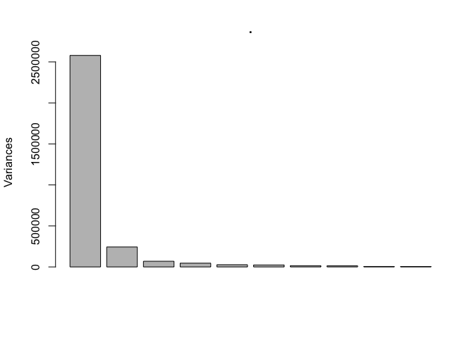

```r
########################################################################################
#### Q5

# q5_data <- data.frame()
# for (i in 1:length(file_names)) {
#   data_ext <- read_csv(file_paths[i]) %>% select(Date, Close)
#   colnames(q5_data)[colnames(q5_data)=="Close"] <- file_names[i]
#   if (i == 1) {
#     data_ext -> q5_data
#   } else {
#     full_join(q5_data, data_ext, by = 'Date') -> q5_data
#   }
# }
#
# save(q5_data, file = 'saved_data/q5_data.RData')
load('../saved_data/q5_data.RData')


q5_data_original <- q5_data


# filling NAs with mean of the column

for (i in 1:ncol(q5_data)) {
  if ((q5_data[which(is.na(q5_data[i])),i] %>% nrow) > 0) {
    q5_data[which(is.na(q5_data[i])),i] <- q5_data[i] %>% na.omit %>% unlist %>% mean
  }
}

#### WITH DATE

# q5_data %>% mutate(Date = as.numeric(Date)) %>% prcomp() -> q5_pca
# q5_pca %>% plot
#
# biplot(q5_pca, cex = 0.8)
# library(ggbiplot)
# q5_pca %>% ggbiplot(obs.scale = 1, var.scale = 1, ellipse = TRUE, circle = TRUE)
#
#
#
# eigv = round(q5_pca$sdev^2/sum(q5_pca$sdev^2)*100, 2)[1:10]
# eigv = data.frame(c(1:10),eigv)
# names(eigv) = c('PCs','Variance')
# plot(eigv,type = "b",col = "darkblue",lwd = 2);grid()
#
#
# library(qcc)
# PCA <- (q5_pca$sdev^2)[1:10]
# names(PCA) = paste0('PC', eigv$PCs)
# qcc::pareto.chart(PCA)
#
#
# first_3_comps <- (round(q5_pca$sdev^2, 2) %>% as.data.frame() %>% slice(1:3) %>% sum())/
#   (round(q5_pca$sdev^2, 2) %>% as.data.frame() %>% sum())
# first_3_comps %>% print



#### WITHOUT DATE

q5_data %>% select(-Date) %>% prcomp() -> q5_pca

cbind(
  q5_data %>% select(Date),
  (q5_data %>% select(-Date) %>% as.matrix) %*% (q5_pca$rotation %>% as.matrix) %>% .[,1:10]
) -> q8_10_pca_data

q5_pca %>% plot
```

[output not shown]

[output cut: 43 more lines]

[output not shown]

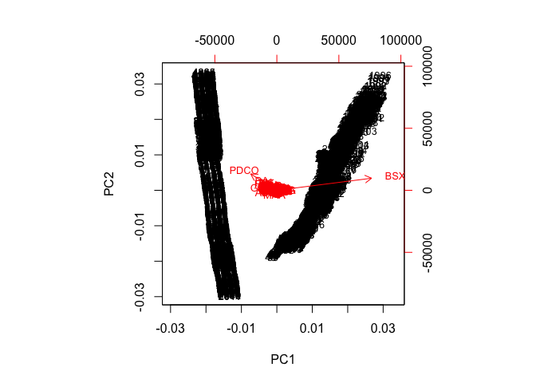

```r
biplot(q5_pca, cex = 0.8)
```

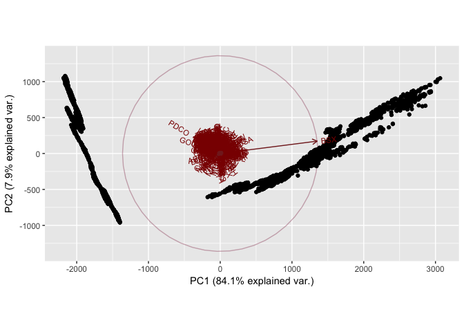

```r
library(ggbiplot)
q5_pca %>% ggbiplot(obs.scale = 1, var.scale = 1, ellipse = TRUE, circle = TRUE)
```

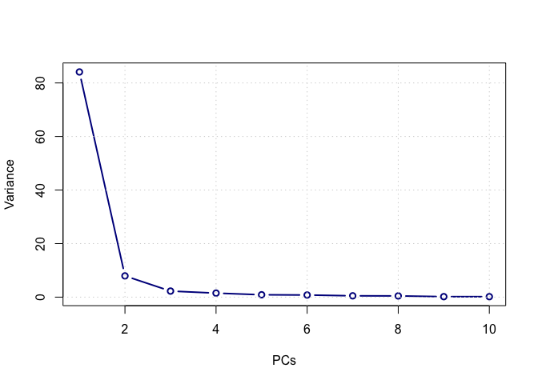

```r
eigv = round(q5_pca$sdev^2/sum(q5_pca$sdev^2)*100, 2)[1:10]
eigv = data.frame(c(1:10),eigv)
names(eigv) = c('PCs','Variance')
plot(eigv,type = "b",col = "darkblue",lwd = 2);grid()
```

```r
library(qcc)
```

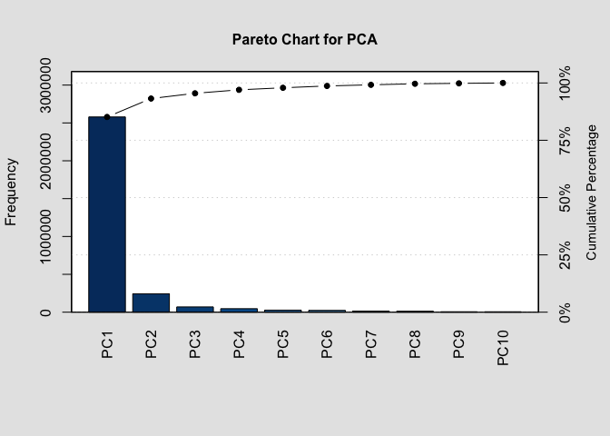

```
##
## Pareto chart analysis for PCA
##           Frequency    Cum.Freq.   Percentage Cum.Percent.
##   PC1  2.578993e+06 2.578993e+06 8.517287e+01 8.517287e+01
##   PC2  2.431197e+05 2.822113e+06 8.029180e+00 9.320205e+01
##   PC3  6.926612e+04 2.891379e+06 2.287557e+00 9.548960e+01
##   PC4  4.587292e+04 2.937252e+06 1.514982e+00 9.700458e+01
##   PC5  2.706237e+04 2.964314e+06 8.937517e-01 9.789834e+01
##   PC6  2.410429e+04 2.988419e+06 7.960593e-01 9.869440e+01
##   PC7  1.503749e+04 3.003456e+06 4.966226e-01 9.919102e+01
##   PC8  1.377732e+04 3.017234e+06 4.550045e-01 9.964602e+01
##   PC9  5.501445e+03 3.022735e+06 1.816887e-01 9.982771e+01
##   PC10 5.216828e+03 3.027952e+06 1.722890e-01 1.000000e+02
```

```r
PCA <- (q5_pca$sdev^2)[1:10]
names(PCA) = paste0('PC', eigv$PCs)
qcc::pareto.chart(PCA)
```

```r
first_3_comps <- (round(q5_pca$sdev^2, 2) %>% as.data.frame() %>% slice(1:3) %>% sum())/
  (round(q5_pca$sdev^2, 2) %>% as.data.frame() %>% sum())
first_3_comps %>% print
```

```
## [1] 0.9428527
```

۶. برای هر نماد اطلاعات بخش مربوطه را از داده constituents استخراج نمایید. برای هر بخش میانگین روزانه قیمت شروع شرکت های آن را محاسبه کنید. سپس با استفاده از میانگین به دست آمده داده ایی با چند ستون که هر ستون یک بخش و هر سطر یک روز هست بسازید. داده مربوط را با داده شاخص های اقتصادی ادغام کنید. بر روی این داده pca بزنید و نمودار biplot آن را تفسیر کنید.

> According to the biplot analysis of our PCA, the real stocks price and the SP500 stocks index tend to explain nearly all of the variance in the stocks market.  
> Putting aside the ‘Real price’; the SP500 index looks like a marvelously good index to explain this much of the complex stocks data!

```r
########################################################################################
#### Q6

library(dplyr)

stocks_data %>% full_join(constituents, by = 'Symbol') %>% group_by(Sector, Date) %>%
  summarise(OpenMean = mean(Open, na.rm = TRUE)) %>% spread(key = 'Sector', value = 'OpenMean') -> sectors_daily_data

indexes_data <- read_csv('../class_data/indexes.csv')
```

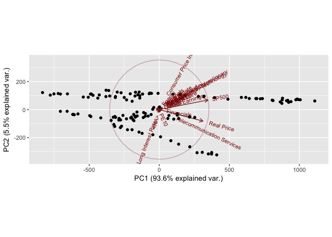

```r
full_join(
  sectors_daily_data,
  indexes_data,
  by = 'Date'
) -> q6_data

#### first approach, removing incomplete records

q6_data %>% .[complete.cases(.),] %>% select(-Date) %>% prcomp -> q6_pca_first_approach

q6_pca_first_approach %>% ggbiplot(obs.scale = 1, var.scale = 1, ellipse = TRUE, circle = TRUE)
```

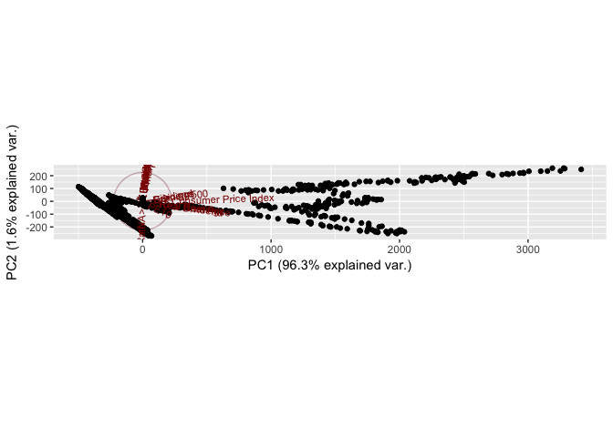

```r
#### second approach, filling NAs with mean of the column

q6_data_second_approach <- q6_data %>% select(-Date)

for (i in 1:ncol(q6_data_second_approach)) {
  if ((q6_data_second_approach[which(is.na(q6_data_second_approach[i])),i] %>% nrow) > 0) {
    q6_data_second_approach[which(is.na(q6_data_second_approach[i])),i] <- q6_data_second_approach[i] %>% na.omit %>% unlist %>% mean
  }
}

q6_data_second_approach %>% prcomp -> q6_pca_second_approach
q6_pca_second_approach %>% ggbiplot(obs.scale = 1, var.scale = 1, ellipse = TRUE, circle = TRUE)
```

۷. روی همه اطلاعات (OHLCV) سهام اپل الگوریتم PCA را اعمال کنید. سپس از مولفه اول برای پیش بینی قیمت شروع سهام در روز آینده استفاده کنید. به سوالات سوال ۴ پاسخ دهید. آیا استفاده از مولفه اول نتیجه بهتری نسبت به داده open price برای پیش بینی قیمت دارد؟

> We’ve used the same method as question 4 for calculating mse except for two things:
> 1. We’re using h2o k-fold functioality for cross validation of our model and data.<>
> 2. We’re using the first principal component of our data instead of Open prices.<> <>  
>    According to the results, we gain improvements by increasing k to around 50 but I’m speculating that after that we are overfitting our model to the provided data and increase in performance is not real.  
>    So I think arounf 50 is the sweet domain for k values.  
>    Finally using the PC instead of opening prices did not improve the results.

```r
########################################################################################
#### Q7

stocks_data_full %>% filter(Symbol == 'AAPL') %>% arrange(desc(Date)) %>% select(-Symbol) -> apple_stocks_data

apple_stocks_data %>% select(-Date) %>% prcomp -> q7_pca


cbind(
  apple_stocks_data %>% select(Open) %>% dplyr::rename(Price = Open),
  (apple_stocks_data %>% select(-Date) %>% as.matrix) %*% (q7_pca$rotation %>% as.matrix) %>% as.data.frame
) %>% select(Price, PC1) %>% dplyr::rename(Day1 = PC1) -> apple_open_prices

get_model_data <- function(k) {
  cbind(
    apple_open_prices,
    apple_open_prices %>% .$Day1 %>% lead %>% as.data.frame %>% dplyr::rename(Day2 = '.')
  ) -> model_data
  column_names <- c('Day2', 'Day1')
  if (k > 1) {
    for (i in 2:k) {
      cbind(
        model_data,
        model_data %>% .$Day1 %>% lead %>% as.data.frame
      ) -> model_data
      column_names <- c(paste('Day', (i+1), sep = ''), column_names)
      colnames(model_data) <- c('Price', column_names)
    }
  }
  return(model_data)
}

library(h2o)
h2o.init()
```

```
##  Connection successful!
##
## R is connected to the H2O cluster:
##     H2O cluster uptime:         39 seconds 167 milliseconds
##     H2O cluster timezone:       Asia/Tehran
##     H2O data parsing timezone:  UTC
##     H2O cluster version:        3.19.0.4257
##     H2O cluster version age:    1 month and 11 days
##     H2O cluster name:           H2O_started_from_R_mohammadmahdi_zpj824
##     H2O cluster total nodes:    1
##     H2O cluster total memory:   1.76 GB
##     H2O cluster total cores:    4
##     H2O cluster allowed cores:  4
##     H2O cluster healthy:        TRUE
##     H2O Connection ip:          localhost
##     H2O Connection port:        54321
##     H2O Connection proxy:       NA
##     H2O Internal Security:      FALSE
##     H2O API Extensions:         XGBoost, Algos, AutoML, Core V3, Core V4
##     R Version:                  R version 3.4.4 (2018-03-15)
```

```r
find_mse_for_kday_model <- function(k) {
  model_data <- k %>% get_model_data %>% as.h2o
  model <- h2o.glm(y = "Price", x = colnames(model_data), training_frame = model_data, family="gaussian" ,nfolds = 5)
  result <- model %>% h2o.performance(model_data) %>% h2o.mse
  return(result)
}

# renaming the column and dataframe in order to use it with the same methods from Q4


# x = 1:100
# y = sapply(x, find_mse_for_kday_model)
# q7_data <- data.frame(number_of_days = x, mean_square_error = y)
# save(q7_data, file = 'Desktop/saved_data/q7_data.RData')

load('../saved_data/q7_data.RData')

 q7_data %>% hchart(type = 'line', hcaes(x = number_of_days, y = mean_square_error))
```

[interactive chart not shown]

۸. نمودار سود نسبی شاخص s&p500 را رسم کنید. آیا توزیع سود نرمال است؟(از داده indexes استفاده کنید.) با استفاده از ده مولفه اول سوال پنج آیا می توانید سود و ضرر شاخص s&p500 را برای روز آينده پیش بینی کنید؟ از یک مدل رگرسیون لاجستیک استفاده کنید. درصد خطای پیش بینی را به دست آورید.

> SP500 is a highly complex stocks index.  
> I’m not surprised that the model’s performance in predicting it’s relative revenue rate is not high and is around 60 percents.

```r
########################################################################################
#### Q8

cbind(
  indexes_data %>% select(Date, SP500),
  indexes_data %>% .$SP500 %>% lead %>% as.data.frame %>% dplyr::rename(Before = '.')
) %>% mutate(relative_revenue = (SP500 - Before)/SP500) %>% .[complete.cases(.),] -> sp500_rel_rev_data

sp500_rel_rev_data %>% .$relative_revenue %>% hcdensity()
```

[interactive chart not shown]

```r
library(nortest)

pearson.test(sp500_rel_rev_data %>% .$relative_revenue)
```

```
##
##  Pearson chi-square normality test
##
## data:  sp500_rel_rev_data %>% .$relative_revenue
## P = 168.51, p-value < 2.2e-16
```

```r
ks.test(sp500_rel_rev_data %>% .$relative_revenue, 'pnorm')
```

```
##
##  One-sample Kolmogorov-Smirnov test
##
## data:  sp500_rel_rev_data %>% .$relative_revenue
## D = 0.45458, p-value < 2.2e-16
## alternative hypothesis: two-sided
```

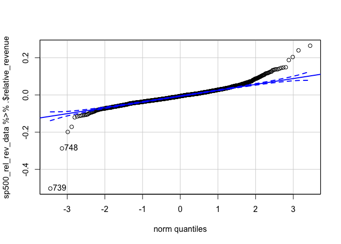

```
## [1] 739 748
```

```r
car::qqp(sp500_rel_rev_data %>% .$relative_revenue)
```

```r
full_join(
  sp500_rel_rev_data %>% mutate(Profit = relative_revenue > 0) %>% select(Date, Profit),
  q8_10_pca_data,
  by = 'Date'
) %>% .[complete.cases(.),] %>% select(-Date) -> q8_model_data

q8_h2o_model_data <- as.h2o(q8_model_data)
h2o.glm(y = "Profit", x = colnames(q8_h2o_model_data), training_frame = q8_h2o_model_data, family="binomial" ,nfolds = 5)
```

```
## Model Details:
## ==============
##
## H2OBinomialModel: glm
## Model ID:  GLM_model_R_1526764130280_2
## GLM Model: summary
##     family  link                               regularization
## 1 binomial logit Elastic Net (alpha = 0.5, lambda = 0.02097 )
##   number_of_predictors_total number_of_active_predictors
## 1                         10                           6
##   number_of_iterations training_frame
## 1                    3  q8_model_data
##
## Coefficients: glm coefficients
##        names coefficients standardized_coefficients
## 1  Intercept    -2.412262                 -0.607604
## 2        PC1     0.000051                  0.081076
## 3        PC2     0.000149                  0.074696
## 4        PC3     0.000941                  0.243075
## 5        PC4     0.000000                  0.000000
## 6        PC5    -0.000791                 -0.133175
## 7        PC6     0.000000                  0.000000
## 8        PC7     0.000000                  0.000000
## 9        PC8     0.000000                  0.000000
## 10       PC9     0.003179                  0.224966
## 11      PC10    -0.006209                 -0.428751
##
## H2OBinomialMetrics: glm
## ** Reported on training data. **
##
## MSE:  0.208823
## RMSE:  0.4569716
## LogLoss:  0.6043125
## Mean Per-Class Error:  0.321456
## AUC:  0.6975135
## Gini:  0.3950269
## R^2:  0.09533217
## Residual Deviance:  157.1213
## AIC:  171.1213
##
```

[output cut: 69 more lines]

```
## ---
##                           mean          sd cv_1_valid   cv_2_valid
## precision           0.47798523 0.067706056  0.6666667    0.4347826
## r2                -0.038114917 0.047886197 0.08603033 -0.082512245
## recall               0.8761039  0.11188687  0.5714286   0.90909094
## residual_deviance     34.92804   3.5238926  27.189243    41.118423
## rmse                0.48628703  0.02117647 0.43453836    0.5048368
## specificity         0.36395893  0.19452752 0.88235295    0.2777778
##                     cv_3_valid  cv_4_valid   cv_5_valid
## precision           0.42105263  0.45833334    0.4090909
## r2                -0.018688716   -0.076464 -0.098939955
## recall                     1.0         1.0          0.9
## residual_deviance    31.475761   36.548992     38.30778
## rmse                0.47081488  0.51501524   0.50622976
## specificity          0.3529412 0.071428575   0.23529412
```

۹. عکسی که در ابتدای متن آمده را در نظر بگیرید. با استفاده از pca عکس را فشرده کنید. سپس نمودار حجم عکس فشرده بر حسب تعداد مولفه اصلی را رسم کنید. بهترین انتخاب برای انتخاب تعداد مولفه ها در جهت فشرده سازی چه عددی است؟

> If we ignore final image quality and just care for the image size, the less components we use, the better results we get!  
> But in a real scenario it’s not the case. increasing the number of PCs used, increases the image size to around 180 kBs for 154 PCs. and afterwards the size decreases with more PCs. I guess if we are happy with the image with less than 34 PCs, we should consider a number of PCs less than or equal to 34. otherwise we could use all 412 and get a size equal to an image with 34 PCs.

```r
########################################################################################
#### Q9

library(EBImage)
image <- readImage('./images/stock.jpg') %>% flip

compress_image <- function(image, comp_count){
  red.weigth   <- 0.2989
  green.weigth <- 0.587
  blue.weigth  <- 0.114
  image <- red.weigth * imageData(image)[,,1] +
           green.weigth * imageData(image)[,,2] +
           blue.weigth  * imageData(image)[,,3]
  pca <- image %>% prcomp(scale=TRUE)

  feature_vector <- pca$rotation[,1:comp_count]
  compact_data <- t(feature_vector) %*% t(image)
  approximate_image <- t(feature_vector %*% compact_data)
  return(approximate_image)
}

save_image <- function(comp_count) {
  image %>% compress_image(comp_count) -> compressed_image
  compressed_image %>% flip %>%
    writeImage(paste0("./images/image_", str_pad(as.character(comp_count), 3, 'left','0'), ".jpg"))
}

# image has 412 principal components
# for (i in 1:412) {
#   i %>% save_image
# }

image_names <- list.files(path="./images", pattern="image_", full.names=T, recursive=FALSE) %>% sort
image_sizes <- image_names %>% file.info %>% .$size

file.info("./images/stock.jpg")$size -> main_image_size

data.frame(number_of_pcs = 1:412, image_sizes = image_sizes) %>%
  hchart(type = 'line', hcaes(x = number_of_pcs, y = image_sizes))
```

[interactive chart not shown]

۱۰. پنج ایده جالبی که روی داده های مالی بالا می توانستیم پیاده کنیم را بیان کنید. (ایده کافی است نیازی به محاسبه بر روی داده نیست.)

> This Ideas come to my mind:
> 1. We can investigate the impact of changes in stocks between competing companies.  
>    As an example what is the effect of change in google stocks on apple stocks. <>
> 2. How much is the impact of introducing a new iPhone model on stocks of apple. <>
> 3. What happens to the stocks market of a company that is on the verge of bankrupcy (many case studies are available thanks to american financial crisis about a decade ago). <>
> 4. Try to extract information about the inflation rate in the emerica’s finance based on overal changes of stocks prices in the history of us stocks market <>
> 5. Train a regression model to predict probability of babkrupcy for ameriacn companies based on the histoty of overall market prices and their market prices <> <>